# Data visualizations based on Tufte’s principles

## Kill · The dual-axis overlay

The kill list, drawn 2 of 3

Two scales, one panel

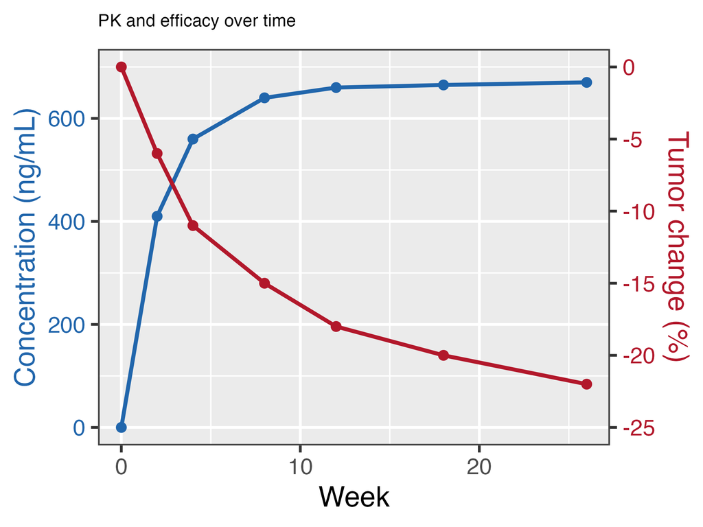

Two panels, one clock

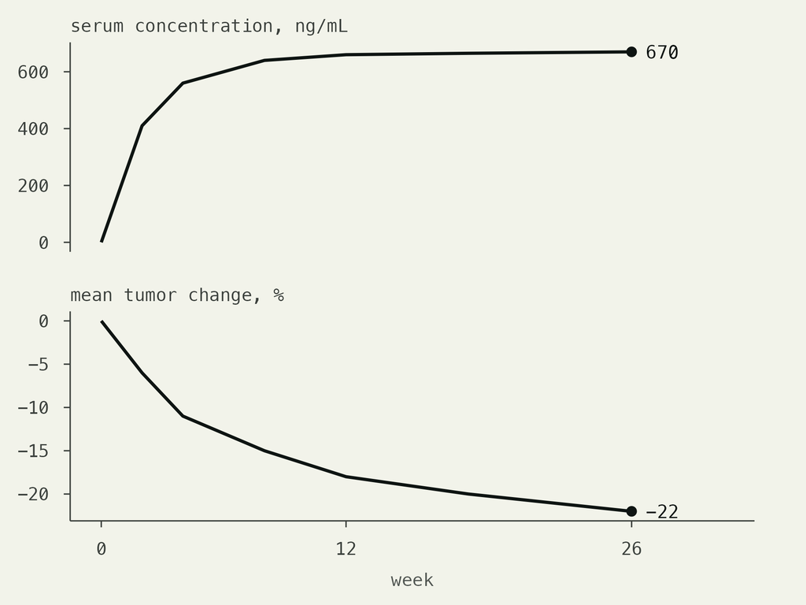

The left panel invites a correlation the data never claimed: rescale either axis and the crossing point moves anywhere you like. The right panel keeps the shared clock, gives each measure its own honest scale, and lets the reader align the timings without being steered.

## Kill · The rainbow heatmap

The kill list, drawn 3 of 3

Hue has no order

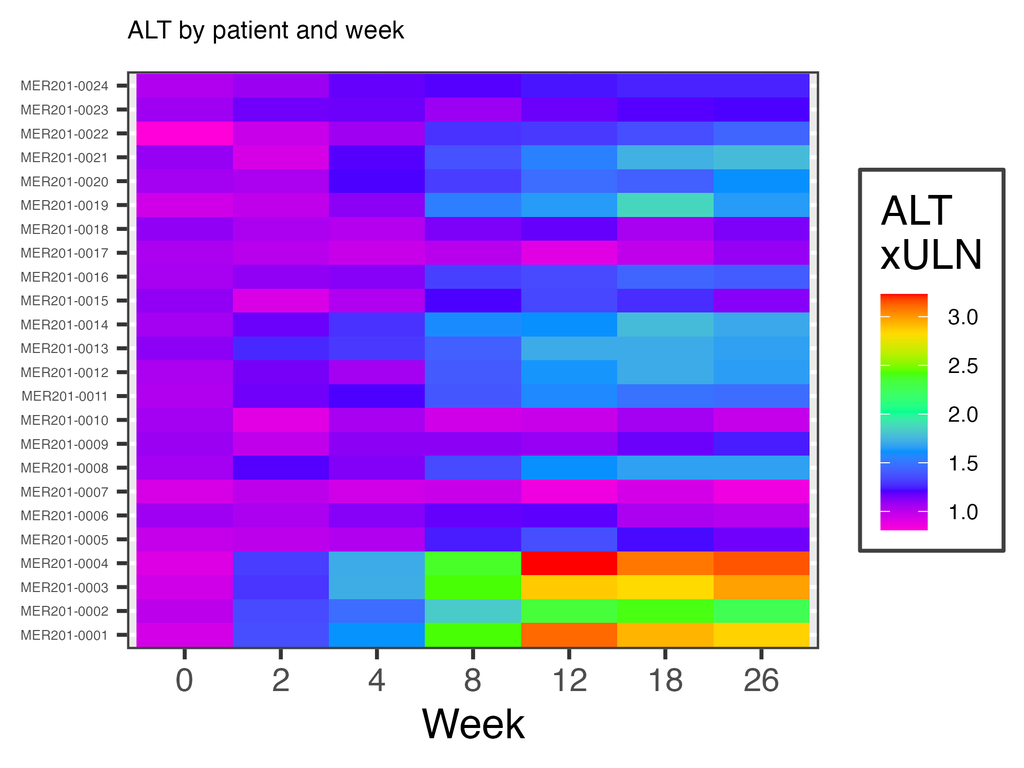

One hue, light to dark, sorted

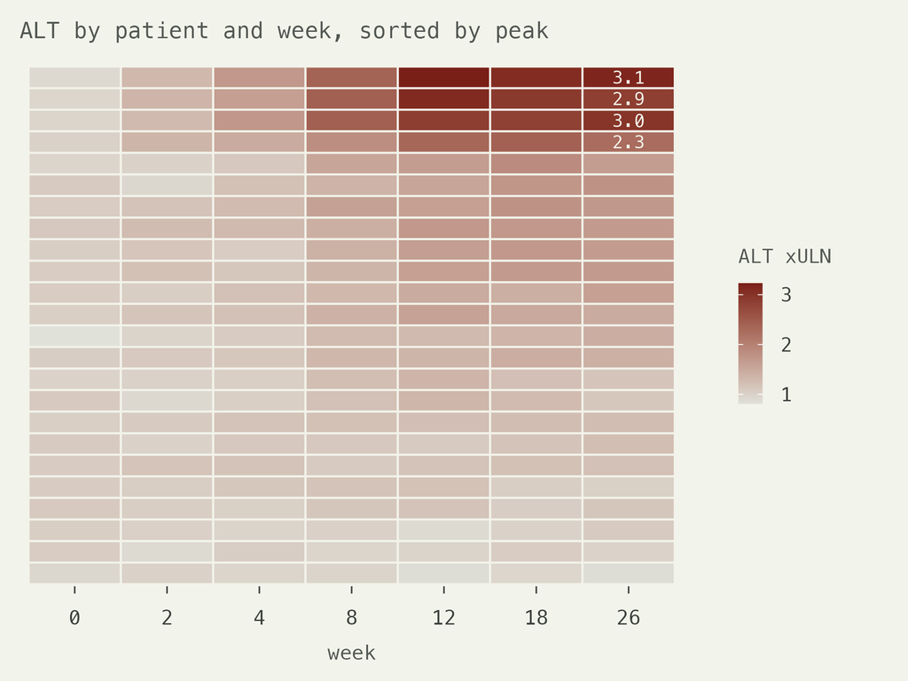

ALT as multiples of ULN, 24 patients, 26 weeks. Is yellow higher than green? The rainbow forces the reader to keep re-checking the legend, and its brightest band lands mid-scale. One hue running light to dark reads without a key, and sorting patients by peak puts the four who crossed 2 xULN, labeled at week 26, in one place instead of scattered.

## The rest of the kill list

| Kill | Use instead | Shown at |
| --- | --- | --- |
| Dynamite plots | Dots and medians, all patients | Rule 1 |
| Legend far from the curves | Direct labels at line ends | Rules 2+3, 9 |
| Grid and frame at data weight | Faint gray, or nothing | Rules 2+3, 7 |
| Truncated bar axes | Zero base, or the number with its CI | Rules 4+5 |
| Bars for ratios | A point with an interval on a log scale | the fix, rule 10 |
| 3D anything | The 2D version | never drawn, on purpose |
| Subgroup panels on mixed scales | One shared scale | Rules 6, 8 |
| “approximately ~42%” | “42.3%” | every caption |
| p-value theater | The estimate and interval, shown | Rule 10 |

If a journal or a sponsor template insists on one of these, comply, and put the Tufte version beside it in the appendix. Reviewers notice.

## Before a figure ships

- **Every patient visible**, or the summary is drawn over the points.
- **Zero-based bars**; truncated line axes labeled.
- **One accent color**, spent on the finding, not the furniture.
- **Direct labels**; a legend only past five groups.
- **Shared scales** across panels and repeat figures.
- **At-risk counts** under every KM plot.
- **Sorted** by estimate, not alphabetically, unless the SAP says otherwise.
- **Type readable from the back**: ticks 12 px, labels 14 px.

> Above all else show the data.  
> Maximize the data-ink ratio.  
> Erase non-data-ink.  
> Erase redundant data-ink.  
> Revise and edit.

> VDQI, p. 105

The fifth line does the work. Every clean panel in this deck is the second draft of the junk panel beside it.

## Sources and reuse

The three books: *The Visual Display of Quantitative Information* (1983), *Envisioning Information* (1990), *Visual Explanations* (1997). Quotes cited by page.

MER-201 and MER-102 are simulated: `R/sim_data.R` generates every dataset, `R/theme_tufte.R` holds the palette and themes, and every figure is plain ggplot2, dplyr, and survival. Render with `quarto render tufte-pharma.qmd`. Reuse freely.